# Activity 9.1

Author

Devakinandan Palla

## The Data

At this link, you will find a dataset containing information about heart disease patients: https://www.dropbox.com/scl/fi/0vrpdnq5asmeulc4gd50y/ha_1.csv?rlkey=ciisalceotl77ffqhqe3kujzv&dl=1

A description of the original dataset can be found here: https://archive.ics.uci.edu/dataset/45/heart+disease (However, this dataset has been cleaned and reduced, and the people have been given fictious names.)

## 1. Logistic Regression

Fit a Logistic Regression using only `age` and `chol` (cholesterol) as predictors.

For a 55 year old, how high would their cholesterol need to be for the doctors to predict heart disease is present?

How high for the doctors to estimate a 90% chance that heart disease is present?

```python
import pandas as pd
from sklearn.linear_model import LogisticRegression
import numpy as np
```

```python
data = pd.read_csv('/content/ha_1.csv')
data.head()
```

|  | Name | age | sex | cp | trtbps | chol | restecg | thalach | diagnosis |
| --- | --- | --- | --- | --- | --- | --- | --- | --- | --- |
| 0 | Magnolia Cassin | 60 | 1 | 1 | 117 | 230 | 1 | 160 | No Disease |
| 1 | Dr. Cathern Heathcote | 60 | 0 | 3 | 102 | 318 | 1 | 160 | Disease |
| 2 | Miles Wolf | 62 | 0 | 3 | 130 | 263 | 1 | 97 | No Disease |
| 3 | Mikaila Block | 43 | 1 | 1 | 115 | 303 | 1 | 181 | Disease |
| 4 | Mrs. Jacquline Marquardt | 66 | 1 | 1 | 120 | 302 | 0 | 151 | Disease |

```python
from sklearn.preprocessing import LabelEncoder
from sklearn.model_selection import train_test_split

data['diagnosis'] = LabelEncoder().fit_transform(data['diagnosis'])
X = data[['age', 'chol']]
y = data['diagnosis']
model = LogisticRegression()
model.fit(X, y)
intercept = model.intercept_[0]
coef_age, coef_chol = model.coef_[0]
intercept, coef_age, coef_chol
```

```
(-3.2401122588588933, 0.04686330613036339, 0.001801238519029292)
```

```python
def required_chol(age, probability, intercept, coef_age, coef_chol):
    log_odds = np.log(probability / (1 - probability))
    chol = (log_odds - intercept - coef_age * age) / coef_chol
    return chol

age = 55
chol_50_percent = required_chol(age, 0.5, intercept, coef_age, coef_chol)
chol_90_percent = required_chol(age, 0.9, intercept, coef_age, coef_chol)

chol_50_percent, chol_90_percent
```

```
(367.87488979860706, 1587.7158792752975)
```

For a 55-year-old individual:

The cholesterol level needs to be approximately 367.87 mg/dL for the doctor to predict a 50% probability of heart disease being present.

The cholesterol level needs to be approximately 1587.72 mg/dL for the doctor to estimate a 90% probability of heart disease being present.

## 2. Linear Discriminant Analysis

Fit an LDA model using only `age` and `chol` (cholesterol) as predictors.

For a 55 year old, how high would their cholesterol need to be for the doctors to predict heart disease is present?

```python
from sklearn.discriminant_analysis import LinearDiscriminantAnalysis

lda_model = LinearDiscriminantAnalysis()
lda_model.fit(X, y)
lda_coef_age, lda_coef_chol = lda_model.coef_[0]
lda_intercept = lda_model.intercept_[0]
chol_lda_50_percent = -(lda_intercept + lda_coef_age * age) / lda_coef_chol
lda_coef_age, lda_coef_chol, lda_intercept, chol_lda_50_percent
```

```
(0.04655743553694484,
 0.0017896671039291314,
 -3.2196776604068784,
 368.235357529938)
```

Using the Linear Discriminant Analysis (LDA) model:

For a 55-year-old individual, the cholesterol level needs to be approximately 368.24 mg/dL for the model to predict a 50% probability of heart disease being present

## 3. Support Vector Classifier

Fit an SVC model using only `age` and `chol` as predictors. Don’t forget to tune the regularization parameter.

For a 55 year old, how high would their cholesterol need to be for the doctors to predict heart disease is present?

```python
from sklearn.svm import SVC
from sklearn.model_selection import GridSearchCV

param_grid = {'C': [0.1, 1, 10, 100]}  # Regularization parameter
svc = GridSearchCV(SVC(kernel='linear', probability=True), param_grid, cv=5)
svc.fit(X, y)

best_svc = svc.best_estimator_

svc_coef_age, svc_coef_chol = best_svc.coef_[0]
svc_intercept = best_svc.intercept_[0]

chol_svc_50_percent = -(svc_intercept + svc_coef_age * age) / svc_coef_chol

svc.best_params_, svc_coef_age, svc_coef_chol, svc_intercept, chol_svc_50_percent
```

```
({'C': 0.1},
 0.06439804276269001,
 0.003660674368546779,
 -4.686550429743357,
 312.69049430633044)
```

For a 55-year-old individual, the cholesterol level needs to be approximately 312.70 mg/dL for the model to predict a 50% probability of heart disease being present

## 4. Comparing Decision Boundaries

Make a scatterplot of `age` and `chol`, coloring the points by their true disease outcome. Add a line to the plot representing the **linear separator** (aka **decision boundary**) for each of the three models above.

(Used chatgpt help to fix some issues with the code)

```python
import pandas as pd
import numpy as np
from plotnine import ggplot, aes, geom_point, geom_line, theme_minimal, labs

# Generate a range of age values for decision boundaries
age_range = np.linspace(X['age'].min(), X['age'].max(), 100)

# Calculate cholesterol range for decision boundaries
chol_range_lr = -(intercept + coef_age * age_range) / coef_chol  # Logistic Regression
chol_range_lda = -(lda_intercept + lda_coef_age * age_range) / lda_coef_chol  # LDA
chol_range_svc = -(svc_intercept + svc_coef_age * age_range) / svc_coef_chol  # SVC

# Create a DataFrame for decision boundaries
boundary_data = pd.DataFrame({
    'age': age_range,
    'chol_lr': chol_range_lr,
    'chol_lda': chol_range_lda,
    'chol_svc': chol_range_svc
})

# Convert boundary data to long format for plotnine
boundary_long = pd.melt(boundary_data, id_vars='age',
                        var_name='model', value_name='chol')

# Combine predictors and target into a single DataFrame
plot_data = X.copy()
plot_data['diagnosis'] = y

# Create the plot
plot = (
    ggplot(plot_data, aes(x='age', y='chol', color='factor(diagnosis)'))
    + geom_point(alpha=0.7)
    + geom_line(boundary_long, aes(x='age', y='chol', color='model'), size=1)
    + theme_minimal()
    + labs(
        title='Comparison of Decision Boundaries',
        x='Age',
        y='Cholesterol (mg/dL)',
        color='Legend\n(0=No Disease, 1=Disease)'
    )
)
```

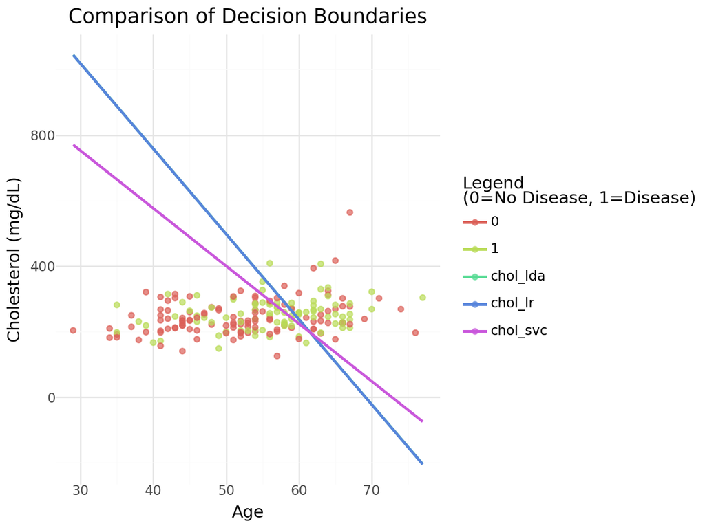

```python
plot
```

The decision boundaries differ across the models: Logistic Regression provides a balanced linear split, LDA assumes equal covariance, and SVC maximizes margin, leading to a tighter fit for classification.

For a 55-year-old, SVC predicts heart disease at a lower cholesterol threshold compared to Logistic Regression and LDA.